# MutFinder

Shaojun Xie

Tuesday, June 28, 2016

## Connect to the server.

I use MobaXterm. Install [Mobaxterm](http://mobaxterm.mobatek.net/download.html)

- Open MabaXterm:

[figure not shown]

- Click **Session**, then type the IP and user name: IP: conte.rcac.purdue.edu User Name should be your email address without @purdue.edu

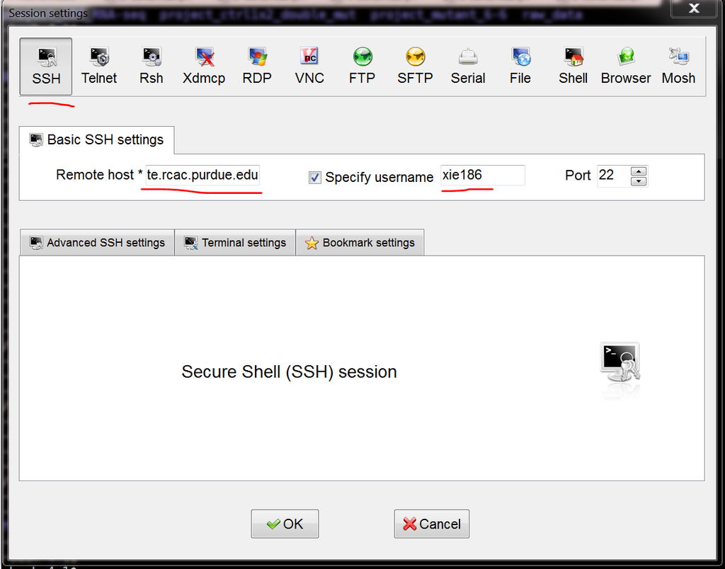

## Create the job files.

### Access your scratch space on Conte in Windows

Go in the your SCRATCH folder: * **Make a new folder. Copy all the file from /depot/zhu132/data/ShaojunXie/zhulab/DrZhaoChunzhao/data to the new folder.**

```bash
cd $CLUSTER_SCRATCH
mkdir test
cd test
cp -r /depot/zhu132/data/ShaojunXie/zhulab/DrZhaoChunzhao/data/* ./
```

For example you have one sample. It should have two files. One file for READ1. One file for READ2. Let’s say the file names are: *Mut_R1.fq.gz* and *Mut_R2.fq.gz*.

*If one sample have 4 files( R1, R2, R3 and R4), then R1 should be the READ2 and R4 should be READ2.*

- Copy the following code into a text file. Let’s say you named it as Mut.qsub

```bash
#!/bin/sh -l
#PBS -q zhu132
#PBS -l nodes=1:ppn=16
#PBS -l naccesspolicy=shared
#PBS -l walltime=10:00:00
#PBS -N bwa
#PBS -o Mut.out
#PBS -e Mut.err
cd $PBS_O_WORKDIR
zcat Mut_R1.fq.gz > Mut_R1.fq
zcat Mut_R2.fq.gz > Mut_R2.fq
#Load the tools we need
module load bioinfo bwa
module load bioinfo samtools
module list

bwa mem -t 15 -R "@RG\tID:Mut\tPL:ILLUMINA\tLB:Mut\tSM:Mut" TAIR10_chr_all.bwaidx Mut_R1.fq Mut_R2.fq |samtools view -bS - |samtools sort - Mut_srt.bam
samtools index Mut_srt.bam
samtools flagstat Mut_srt.bam > Mut_srt.stat
## Remove PCR duplication
#module load bioinfo picard-tools/1.119
java -Xmx10g -jar /group/bioinfo/apps/apps/picard-tools-1.119/MarkDuplicates.jar I=Mut_srt.bam O=Mut_dedup.bam M=Mut_dedup.matrics AS=true
```

- Submit the job:

```bash
## DOS/MAC to UNIX text file format converting
dos2unix Mut.qsub
qsub Mut.qsub
```

For each sample you can do this. Once you do this for all the samples. You will get a *dedup.bam file for each sample. Let’s say you have 3 samples including WT:

WT_dedup.bam Mut_dedup.bam Mut2_dedup.bam

## Call variants (SNP and InDels)

```bash
#!/bin/sh -l
#PBS -q zhu132
#PBS -l nodes=1:ppn=16
#PBS -l naccesspolicy=shared
#PBS -l walltime=10:00:00
#PBS -N bwa
#PBS -o HaplotypeCaller.out
#PBS -e HaplotypeCaller.err
cd $PBS_O_WORKDIR
java -Xmx16g -XX:-UseGCOverheadLimit -jar /group/bioinfo/apps/apps/GATK-3.6.0/GenomeAnalysisTK.jar -T HaplotypeCaller -R TAIR10_chr_all.fasta -I WT_dedup.bam -I Mut_dedup.bam -I Mut2_dedup.bam -stand_call_conf 30 -stand_emit_conf 10 -o output.raw.snps.indels.vcf
```

## Create the figure to view the potential region and do snpEff

```bash
perl mutmap_gatk.pl output.raw.snps.indels.vcf WT Mut |sort -k1,1 -k2,2n > mutmap_snp_index_Mut.txt
module load bioinfo r

R --vanilla --slave --geno_info TAIR10_chr_all.ideogram --var_info mutmap_snp_index_Mut.txt --out mutmap_snp_index_Mut.pdf < mutmap_snp_index.R

perl mutmap_gener_reg_max.pl output.raw.snps.indels.vcf WT Mut mutmap_snp_index_Mut.txt > mutmap_snp_index_Mut.all.vcf
java -jar snpEff_4.1/snpEff.jar eff -no-downstream -no-intergenic -no-upstream  athalianaTair10 mutmap_snp_index_Mut.all.vcf   > mutmap_snp_index_Mut.all.eff
```

You can copy this part to a file.

```bash
dos2unix test.sh
sh test.sh
```

## References:

Conte guide: https://www.rcac.purdue.edu/compute/conte/guide/